# Accessibilité

Clémence Bracq

2023-10-30

# Des inégalités d’accessibilité : ségrégation sanitaire liée à ségrégation sociale et ethnique?

idée pour aller plus loin : Regarder les variables admins de segreg (pct_immi et par type de nationalité)? le turnover(pct_sedent, emmenagés plus d’un an)?

## Stat desc segreg

```
                   group1_rec
l_immi_rec          Immigré DROM  G2 immigré G2 DROM Autre Ensemble
  Majorité immigrée  27.4    25.6  24.1       22.2     7.8  12.5
  mixte              22.1    17.8  20.4       18.1    10.0  12.9
  Minorité immigrée  42.8    45.3  48.5       52.4    75.5  67.6
  Refus/NSP           7.7    11.3   7.1        7.3     6.7   6.9
  Total             100.0   100.0 100.0      100.0   100.0 100.0
```

## Dans ma commune, établissements/APL

### APL

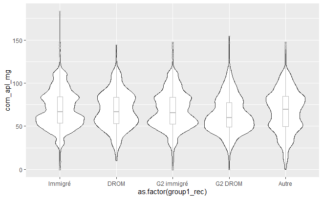

```r
ggsurvey(indiv_bdd_pd, aes(x=as.factor(group1_rec), y=com_apl_mg)) +
  geom_violin()+
  geom_boxplot(width=0.1, color="grey", alpha=0.2)
```

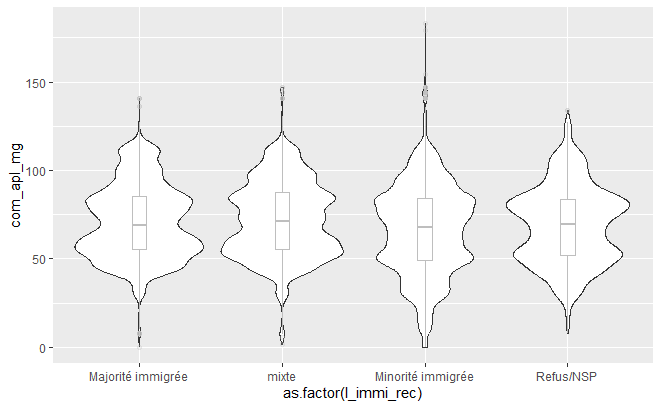

```r
ggsurvey(indiv_bdd_pd, aes(x = as.factor(l_immi_rec), y=com_apl_mg)) +
  geom_violin()+geom_boxplot(width=0.1, color="grey", alpha=0.2)
```

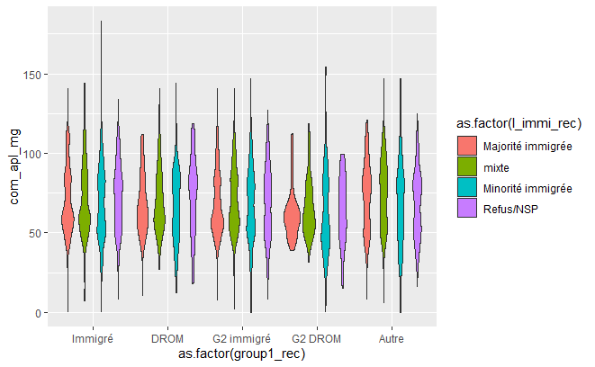

```r
ggsurvey(indiv_bdd_pd, aes(x=as.factor(group1_rec), y=com_apl_mg, fill= as.factor(l_immi_rec))) +
  geom_violin()
```

```r
# +
#   xlab("Réitération")+
#   ylab("Âge au moment de la condamnation")+
#   labs(fill = "Sexe")
```

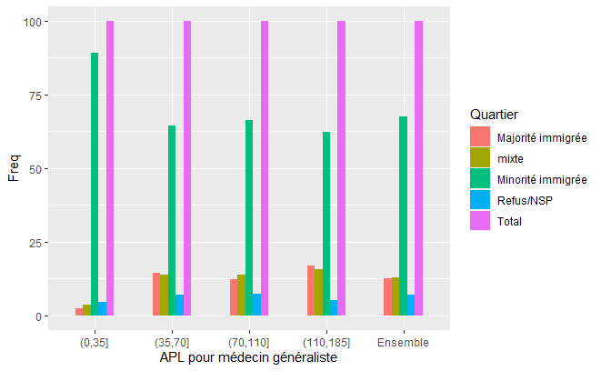

```r
tb1 <- data.frame(cprop(svytable(~l_immi_rec+com_apl_mg_rec, indiv_bdd_pd)))

ggplot(tb1, aes(x = com_apl_mg_rec, y= Freq, fill = l_immi_rec)) +
  geom_bar(stat="identity", width=.5, position = "dodge") +
  xlab("APL pour médecin généraliste")+
  labs(fill = "Quartier")
```

L’accessibilité a l’air plus compliquée pour les personnes habitant dans des quartiers à minorité immigrée.

### Au sein des villes?

#### APL

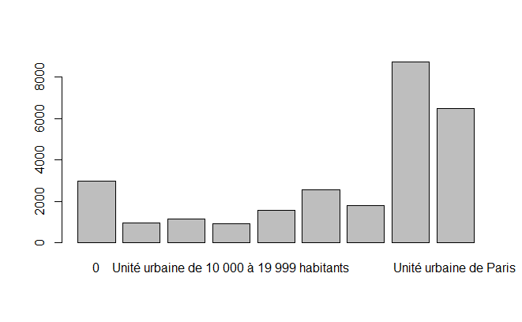

```r
barplot(table(indiv_bdd$tuu2017))
```

```r
indiv_bdd_ville <- indiv_bdd %>% filter(indiv_bdd$tuu2017 %in% c("Unité urbaine de 200 000 à 1 999 999 habitants", "Unité urbaine de Paris"))# on garde plus de la moitié des gens, 56% exactement
```

```r
indiv_bdd_ville_pd <- svydesign(ids = indiv_bdd_ville$ident_fa, data = indiv_bdd_ville, weights = indiv_bdd_ville$poidsi)
```

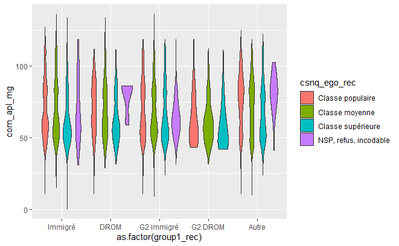

```r
ggsurvey(indiv_bdd_ville_pd, aes(x=as.factor(group1_rec), y=com_apl_mg, fill = csnq_ego_rec)) +
  geom_violin()
```

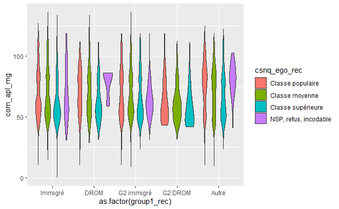

```r
ggsurvey(indiv_bdd_ville_pd, aes(x=as.factor(group1_rec), y=com_apl_mg, fill = csnq_ego_rec)) +
  geom_violin()
```

Parmi les enquêté.e.s habitant dans de grandes villes (plus de 200000 habitants), les personnes ni immigrées ni descendant ni DROM sont ceux qui ont l’accessibilité à un medgé la plus facile. On remarque cependant une dégradation avec les DROM et descndants

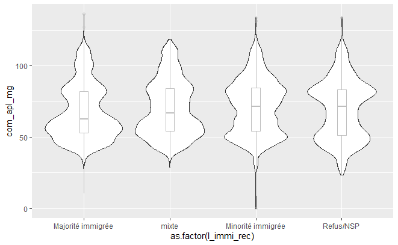

```r
ggsurvey(indiv_bdd_ville_pd, aes(x = as.factor(l_immi_rec), y=com_apl_mg)) +
  geom_violin()+geom_boxplot(width=0.1, color="grey", alpha=0.2)
```

Les communes avec une majorité immigrée ont moins souvent accès à un medgé (surtout en termes de médiane)

#### Etablissements

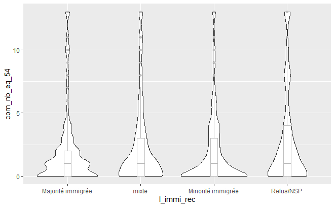

```r
ggsurvey(indiv_bdd_ville_pd, aes(x = l_immi_rec,
  y=com_nb_eq_54)) +
  geom_violin()+geom_boxplot(width=0.1, color="grey", alpha=0.2)
```

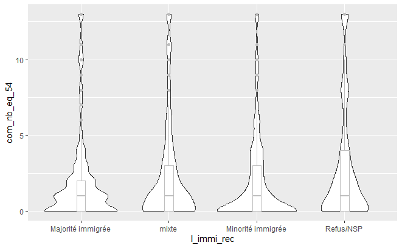

```r
ggsurvey(indiv_bdd_ville_pd, aes(x = l_immi_rec,
  y=com_nb_eq_54)) +
  geom_violin()+geom_boxplot(width=0.1, color="grey", alpha=0.2)
```

## Codes des variables

Caractériser le quartier : L_QUART_SECU L_QUART_REPUE L_QUART_REPUQ L_IMMIE

nb_eq_54 Établissement santé court séjour

nb_eq_55 Établissement santé moyen séjour

nb_eq_56 Établissement santé long séjour

nb_eq_57 Établissement psychiatrique

nb_eq_58 Centre lutte cancer

nb_eq_59 Urgences

nb_eq_60 Maternité

nb_eq_61 Centre de santé

nb_eq_62 Structure psychiatrique en ambulatoire

nb_eq_63 Centre médecine préventive

nb_eq_64 Dialyse

nb_eq_65 Hospitalisation à domicile

APL_DENT Chirurgiens-dentistes libéraux (version 2013) APL_GYN Gynécologues libéraux APL_INF Infirmiers libéraux APL_MAS Masseurs-kinésithérapeutes libéraux APL_MG Médecins généralistes libéraux APL_MG40 Médecins généralistes libéraux de moins de 40 ans APL_OPH Ophtalmologues libéraux APL_PED Pédiatres libéraux APL_PHAR Pharmaciens libéraux APL_PSY Psychiatres libéraux APL_SAGF Sage-femme libérales